# Prediction of Weight Lifting Activity

Berthold Allgeier

19 December 2016

# 1 Background

Using devices such as Jawbone Up, Nike FuelBand, and Fitbit it is now possible to collect a large amount of data about personal activity relatively inexpensively. These type of devices are part of the quantified self movement - a group of enthusiasts who take measurements about themselves regularly to improve their health, to find patterns in their behavior, or because they are tech geeks. One thing that people regularly do is quantify how much of a particular activity they do, but they rarely quantify how well they do it. In this project, your goal will be to use data from accelerometers on the belt, forearm, arm, and dumbell of 6 participants. They were asked to perform barbell lifts correctly and incorrectly in 5 different ways. More information is available from the website here: http://groupware.les.inf.puc-rio.br/har (see the section on the Weight Lifting Exercise Dataset).

# 2 Data

The training data for this project are available here:

https://d396qusza40orc.cloudfront.net/predmachlearn/pml-training.csv

The test data are available here:

https://d396qusza40orc.cloudfront.net/predmachlearn/pml-testing.csv

The data for this project come from this source: http://groupware.les.inf.puc-rio.br/har. If you use the document you create for this class for any purpose please cite them as they have been very generous in allowing their data to be used for this kind of assignment.

# 3 What to submit

# 3 Process and approach

The process will start loading the required libraries. Then the data files for training and testing are loaded and cross-validation is performed. The data is then cleaned and preprocessed. Once this is done, some prediction models will be built and checked in order to selected the best approach. The selected one will be used to predict the 20 observations provided in the testing data file.

## 3.1 Load Libraries and setting seed.

The libraries needed are uploaded and a seed is set to ensure reproducibility.

```r
library(caret)
library(randomForest)
library(rpart)
library(rattle)
set.seed(12345)
```

## 3.2 Load data

The training and testing files are loaded, replacing empty spaces and divisions by cero with NA values.

```r
training_file <- read.csv("pml-training.csv", na.strings=c("","#DIV/0!", "NA"))
testing_file <- read.csv('pml-testing.csv', na.strings=c("","#DIV/0!", "NA"))
```

## 3.3 Cross-validation

Data slicing is used to perform cross-validation, allocating 75% of the training data to the training set and 25% to the testing set.

```r
training_data <- createDataPartition(y=training_file$classe, p=0.75, list=FALSE)
training_set <- training_file[training_data, ]
testing_set <- training_file[-training_data, ]
dim(training_set)
```

```
## [1] 14718   160
```

```r
dim(testing_set)
```

```
## [1] 4904  160
```

## 3.4 Clean data

The data files have many variables and many NA values. The approach is section is to reduce, when possible, the number of variables. This can be one with variables that cannot treated as predictors and those with most of their values missing.

The first 7 columns include an observation id (1), username (2), timestamps (3-5) and window information (6-7) that cannot be used as predictors so they are removed.

```r
training_set <- training_set[,-c(1:7)]
testing_set <- testing_set[,-c(1:7)]
testing_file <- testing_file[,-c(1:7)]
```

```r
training_set<-training_set[,colSums(is.na(training_set)) == 0]
testing_set <-testing_set[,colSums(is.na(testing_set)) == 0]
testing_file <-testing_file[,colSums(is.na(testing_file)) == 0]

dim(training_set)
```

```
## [1] 14718    53
```

```r
dim(testing_set)
```

```
## [1] 4904   53
```

```r
dim(testing_file)
```

```
## [1] 20 53
```

## 3.5 Preprocess data

All variables with low variance are also removed from the sets.

```r
nearzero_var <- nearZeroVar(training_set, saveMetrics=TRUE)
training_set <- training_set[, nearzero_var$nzv == FALSE]
```

## 3.6 Build model

Three models for prediction will be tested: classification tree, random forest and boosting.

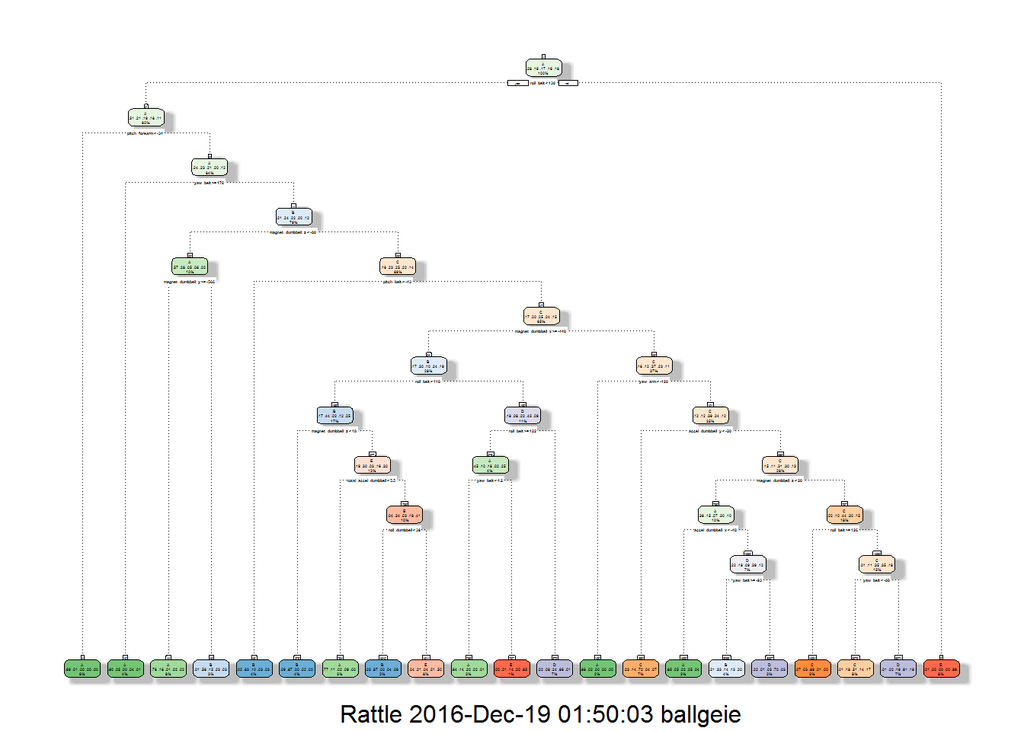

```r
modelRP <- rpart(classe ~ ., data=training_set, method="class")
fancyRpartPlot(modelRP)
```

```r
modelRF <- randomForest(classe ~ ., data=training_set, method="class")
modelRF
```

```
##
## Call:
##  randomForest(formula = classe ~ ., data = training_set, method = "class")
##                Type of random forest: classification
##                      Number of trees: 500
## No. of variables tried at each split: 7
##
##         OOB estimate of  error rate: 0.46%
## Confusion matrix:
##      A    B    C    D    E  class.error
## A 4183    1    0    0    1 0.0004778973
## B   10 2836    2    0    0 0.0042134831
## C    0   14 2552    1    0 0.0058433970
## D    0    0   26 2383    3 0.0120232172
## E    0    0    1    9 2696 0.0036954915
```

```r
modelLB <- train(classe ~ ., data = training_set, method = "LogitBoost")
print(modelLB)
```

```
## Boosted Logistic Regression
##
## 14718 samples
##    52 predictor
##     5 classes: 'A', 'B', 'C', 'D', 'E'
##
## No pre-processing
## Resampling: Bootstrapped (25 reps)
## Summary of sample sizes: 14718, 14718, 14718, 14718, 14718, 14718, ...
## Resampling results across tuning parameters:
##
##   nIter  Accuracy   Kappa
##   11     0.8207016  0.7694494
##   21     0.8707398  0.8347951
##   31     0.8930667  0.8639476
##
## Accuracy was used to select the optimal model using  the largest value.
## The final value used for the model was nIter = 31.
```

## 3.7 Check model

The three models defined are now tested.

```r
predictionRP <- predict(modelRP, testing_set, type = "class")
confusionMatrix(predictionRP, testing_set$classe)
```

```
## Confusion Matrix and Statistics
##
##           Reference
## Prediction    A    B    C    D    E
##          A 1260  156   33   40   23
##          B   52  555   73   52   52
##          C   24  136  575   83   95
##          D   40   33  150  513   89
##          E   19   69   24  116  642
##
## Overall Statistics
##
##                Accuracy : 0.7229
##                  95% CI : (0.7101, 0.7354)
##     No Information Rate : 0.2845
##     P-Value [Acc > NIR] : < 2.2e-16
##
##                   Kappa : 0.6486
##  Mcnemar's Test P-Value : < 2.2e-16
##
## Statistics by Class:
##
##                      Class: A Class: B Class: C Class: D Class: E
## Sensitivity            0.9032   0.5848   0.6725   0.6381   0.7125
## Specificity            0.9282   0.9421   0.9165   0.9239   0.9430
## Pos Pred Value         0.8333   0.7079   0.6298   0.6218   0.7379
## Neg Pred Value         0.9602   0.9044   0.9298   0.9287   0.9358
## Prevalence             0.2845   0.1935   0.1743   0.1639   0.1837
## Detection Rate         0.2569   0.1132   0.1173   0.1046   0.1309
## Detection Prevalence   0.3083   0.1599   0.1862   0.1682   0.1774
## Balanced Accuracy      0.9157   0.7635   0.7945   0.7810   0.8278
```

```r
predictionRF <- predict(modelRF, testing_set, type = "class")
confusionMatrix(predictionRF, testing_set$classe)
```

```
## Confusion Matrix and Statistics
##
##           Reference
## Prediction    A    B    C    D    E
##          A 1395    6    0    0    0
##          B    0  939    2    0    0
##          C    0    4  852    7    1
##          D    0    0    1  797    4
##          E    0    0    0    0  896
##
## Overall Statistics
##
##                Accuracy : 0.9949
##                  95% CI : (0.9925, 0.9967)
##     No Information Rate : 0.2845
##     P-Value [Acc > NIR] : < 2.2e-16
##
##                   Kappa : 0.9936
##  Mcnemar's Test P-Value : NA
##
## Statistics by Class:
##
##                      Class: A Class: B Class: C Class: D Class: E
## Sensitivity            1.0000   0.9895   0.9965   0.9913   0.9945
## Specificity            0.9983   0.9995   0.9970   0.9988   1.0000
## Pos Pred Value         0.9957   0.9979   0.9861   0.9938   1.0000
## Neg Pred Value         1.0000   0.9975   0.9993   0.9983   0.9988
## Prevalence             0.2845   0.1935   0.1743   0.1639   0.1837
## Detection Rate         0.2845   0.1915   0.1737   0.1625   0.1827
## Detection Prevalence   0.2857   0.1919   0.1762   0.1635   0.1827
## Balanced Accuracy      0.9991   0.9945   0.9968   0.9950   0.9972
```

```r
predictionLB <- predict(modelLB, testing_set)
confusionMatrix(predictionLB, testing_set$classe)
```

```
## Confusion Matrix and Statistics
##
##           Reference
## Prediction    A    B    C    D    E
##          A 1303   85   11   16   10
##          B   15  667   58   12   29
##          C    6   42  624   59   31
##          D    6    4   22  552   25
##          E    2   16    5   11  709
##
## Overall Statistics
##
##                Accuracy : 0.8924
##                  95% CI : (0.8827, 0.9015)
##     No Information Rate : 0.3083
##     P-Value [Acc > NIR] : < 2.2e-16
##
##                   Kappa : 0.8623
##  Mcnemar's Test P-Value : < 2.2e-16
##
## Statistics by Class:
##
##                      Class: A Class: B Class: C Class: D Class: E
## Sensitivity            0.9782   0.8194   0.8667   0.8492   0.8818
## Specificity            0.9592   0.9675   0.9617   0.9845   0.9903
## Pos Pred Value         0.9144   0.8540   0.8189   0.9064   0.9542
## Neg Pred Value         0.9900   0.9585   0.9730   0.9736   0.9734
## Prevalence             0.3083   0.1884   0.1667   0.1505   0.1861
## Detection Rate         0.3016   0.1544   0.1444   0.1278   0.1641
## Detection Prevalence   0.3299   0.1808   0.1764   0.1410   0.1720
## Balanced Accuracy      0.9687   0.8934   0.9142   0.9168   0.9361
```

The best accuracy is provided by the random forest model, followed by boosting and classification tree. The random forest model will then be used for the final preciction.

## 3.8 Predict test data

The results of the prediction are diplayed.

```r
testing_file$classe <- predict(modelRF,testing_file)
testing_file$classe
```

```
##  [1] B A B A A E D B A A B C B A E E A B B B
## Levels: A B C D E
```

# 5 Conclusion

## 5.1 Model building

The three prediction models choosen are among the most popular ones, specially boosting and random forest.

## 5.2 Cross validation

As the number of observations is big enough, cross-validation is done by splitting the training file into 75% for training data and 25% for testing data.